# Assessment review of Megrim (*Lepidorhombus whiffiagonis*) in Divisions 7.b-k, 8.a, 8.b, and 8.d

### Residuals plot

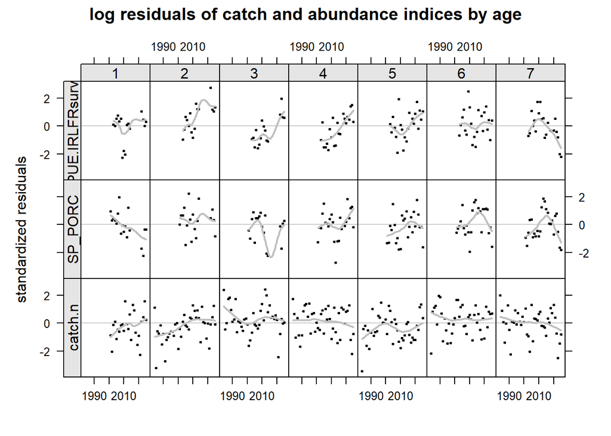

Figure 32: The catch-at-age and index-at-age (Porcupine and IRLFR) residuals in the assessment, after changing the fishing mortality model.

### Observed and predicted catches plot

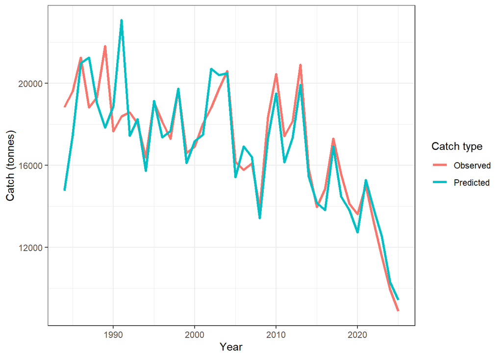

Figure 33: Comparison of observed and predicted catch in the assessment, after changing the fishing mortality model.

## Use of alternative stock-recruitment models

Following the external reviewer’s recommendation to “include a stock–recruitment relationship (e.g. Beverton and Holt) in the model to stabilize the fit”, alternative stock-recruitment functions were analised and finally the beverton and Hold with a CV of 30% was alternatively used.

Time series of recruitment estimates generated by the assessment model using data up to 2019 are presented in Figure 34. This figure compare the original stock-recruitment model, which is based on a year-specific factor, with alternative estimates derived from different stock recruitment functions (ricker, bevholt and hockey) with CV equal to 30%.

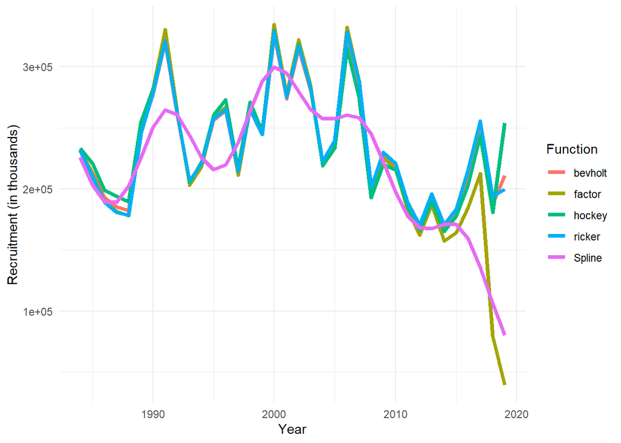

Figure 34: Time series of recruitment estimates produced by the assessment model using data up to 2019, comparing the original stock-recruitment model (based on factor(year)) with alternative estimates using a different stock-recruitment relationship functions (cv = 0.3 in all the cases).

### Retrospective analysis plot

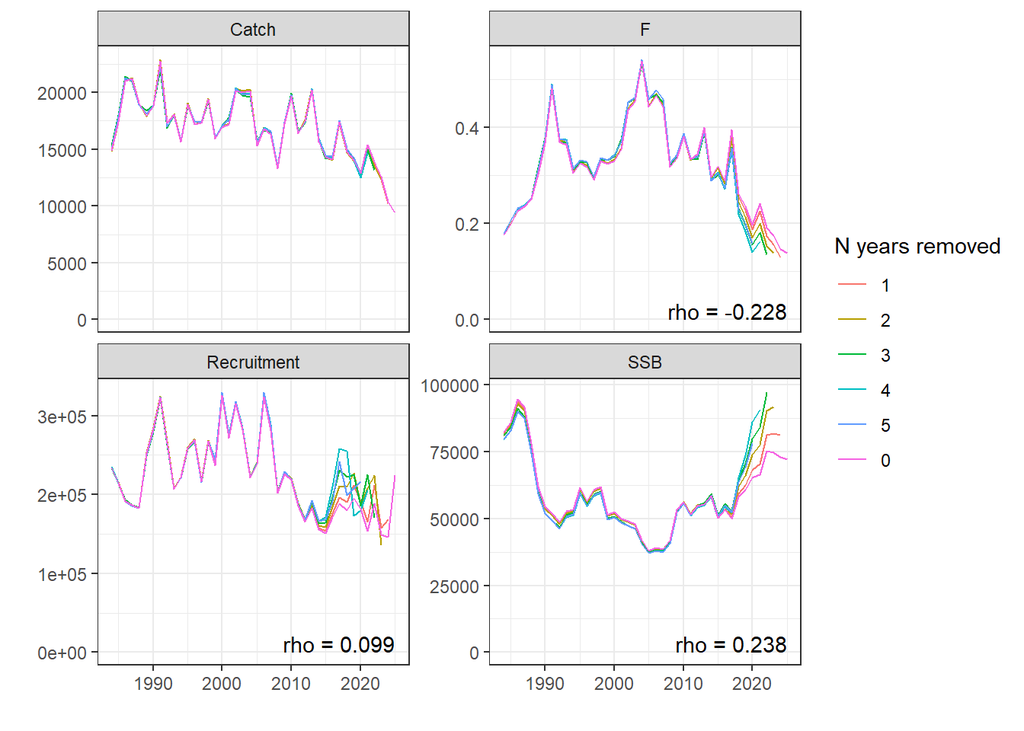

Figure 35: Retrospective analysis showing time series and Mohn’s rho values for median catch, fishing mortality (F, ages 3-6), recruitment (age 1), and spawning stock biomass (SSB), after changing the stock-recruitment model.

### Selectivity and catchability plot

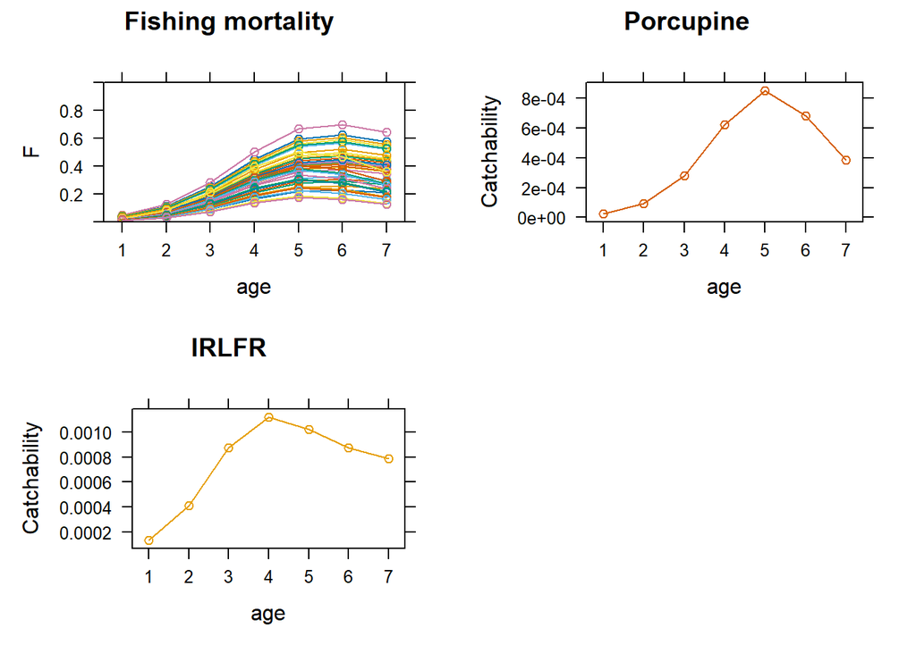

Figure 36: Fishery selectivity and indices catchabilities estimates from the assessment, after changing the stock-recruitment model.

### Residuals plot

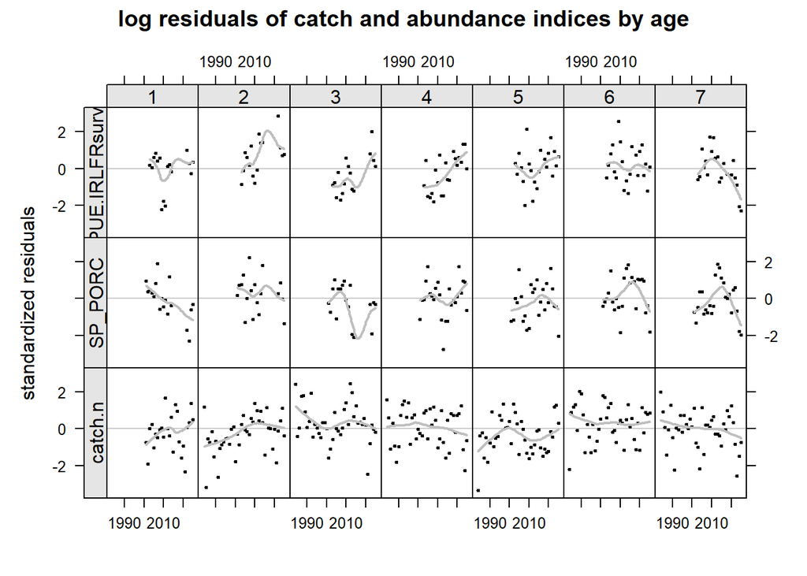

Figure 37: The catch-at-age and index-at-age (Porcupine and IRLFR) residuals in the assessment, after changing the stock-recruitment model.

### Observed and predicted catches plot

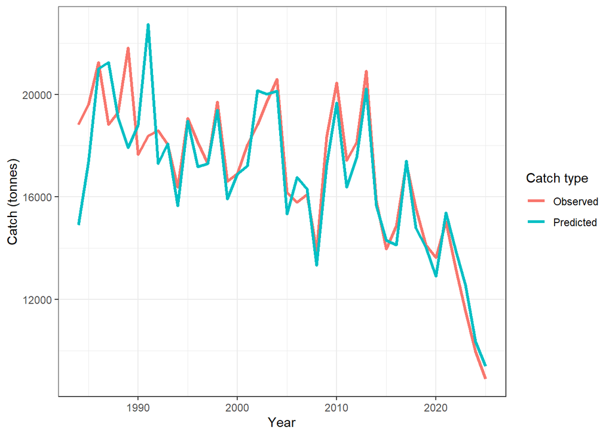

Figure 38: Comparison of observed and predicted catch in the assessment, after changing the stock-recruitment model.

## Include separatelly the three surveys

Two surveys (EVHOE and IGFS) that comprise the IRLF combined index are include combined in IGFS survey. Ernesto Jardin propose to include them separatelly.

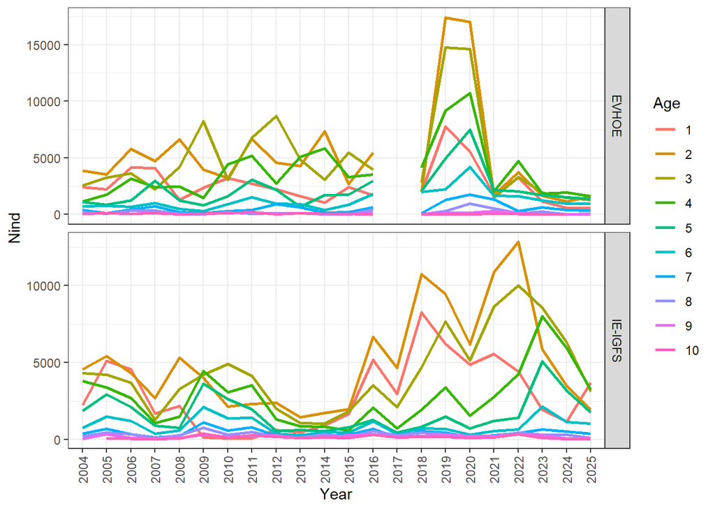

### Changes in the model configuration

In EVHOE remove the 2019 and 2020 years data.

### Retrospective analysis plot

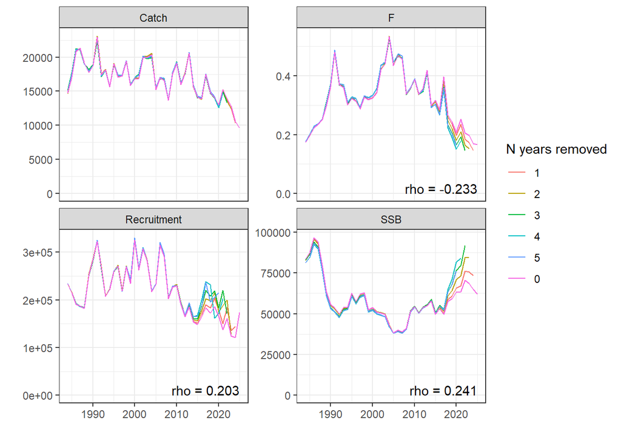

Figure 40: Retrospective analysis showing time series and Mohn’s rho values for median catch, fishing mortality (F, ages 3-6), recruitment (age 1), and spawning stock biomass (SSB), after including EVHOE and IGFS separatelly.

### Selectivity and catchability plot

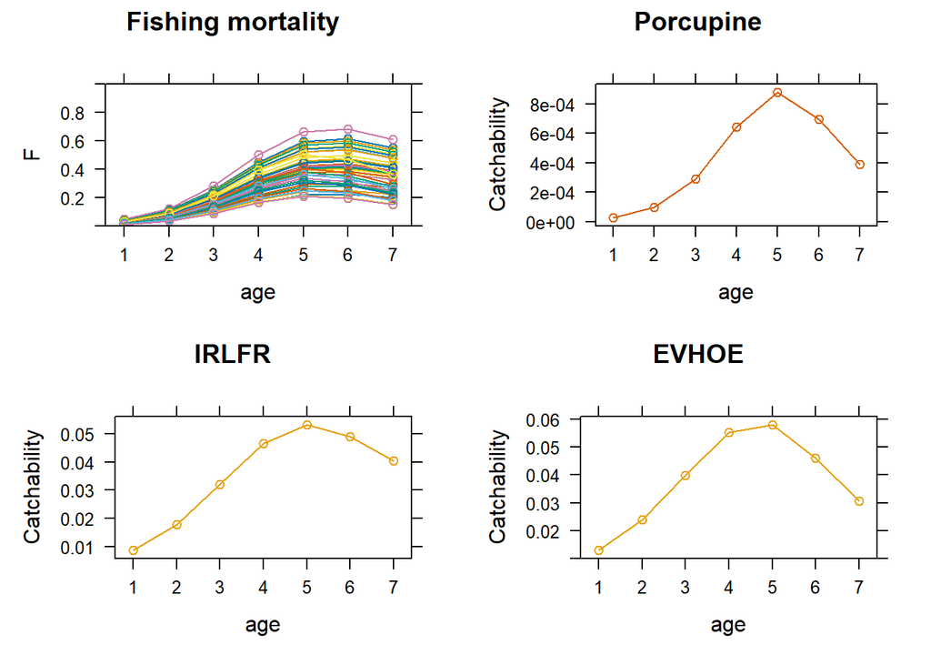

Figure 41: Fishery selectivity and indices catchabilities estimates from the assessment, after including EVHOE and IGFS separatelly.

### Residuals plot

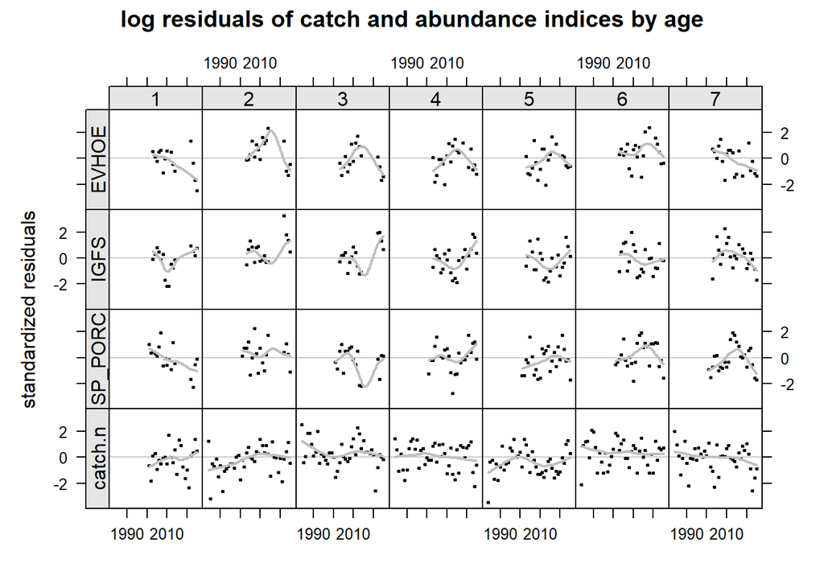

### Observed and predicted catches plot

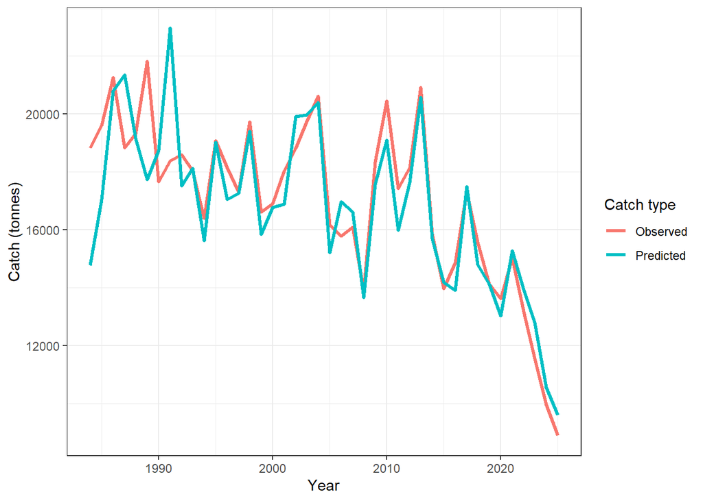

Figure 43: Comparison of observed and predicted catch in the assessment, after including EVHOE and IGFS separatelly.

## Use MCMC and tensor in the fishing mortality with combined index

### Retrospective analysis plot

```r
qmod <- list(~s(age, k = 4), ~s(age, k = 4))
fmod <- ~te(age, year, k = c(5, 25))
srmod <- ~ bevholt(CV=0.3)
n1mod <- ~s(age, k = 3)
vmod <- list(~s(age, k = 3), ~1, ~1)
```

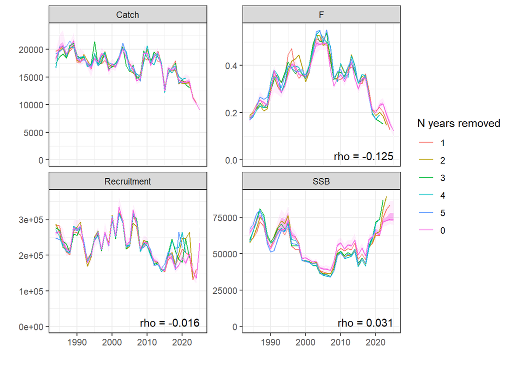

Figure 44: Retrospective analysis showing time series and Mohn’s rho values for median catch, fishing mortality (F, ages 3-6), recruitment (age 1), and spawning stock biomass (SSB), after including mcmc and tensor in the fishing mortality.

### Selectivity and catchability plot

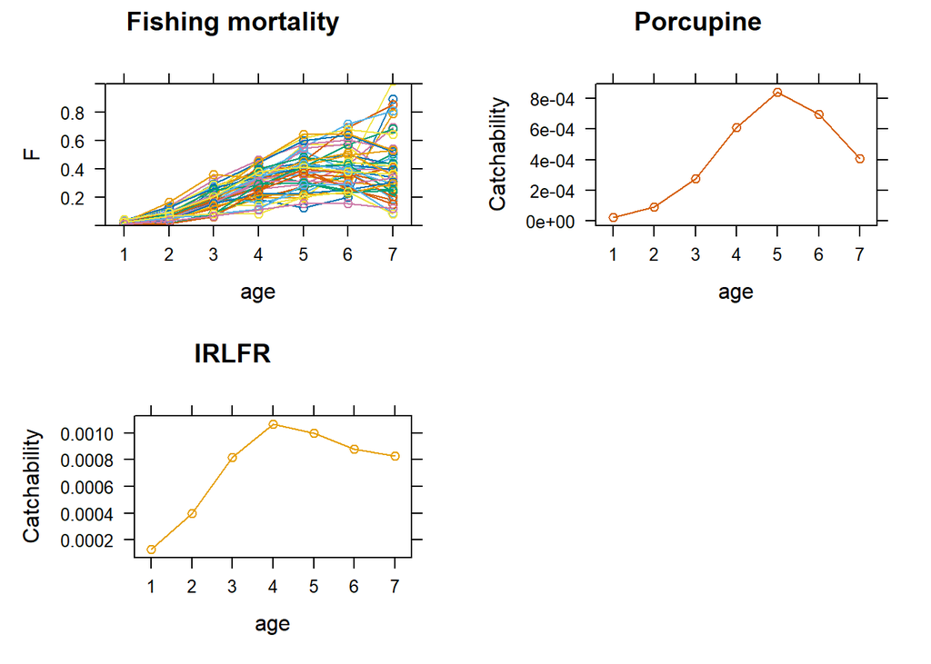

Figure 45: Fishery selectivity and indices catchabilities estimates from the assessment, after including mcmc and tensor in the fishing mortality.

### Residuals plot

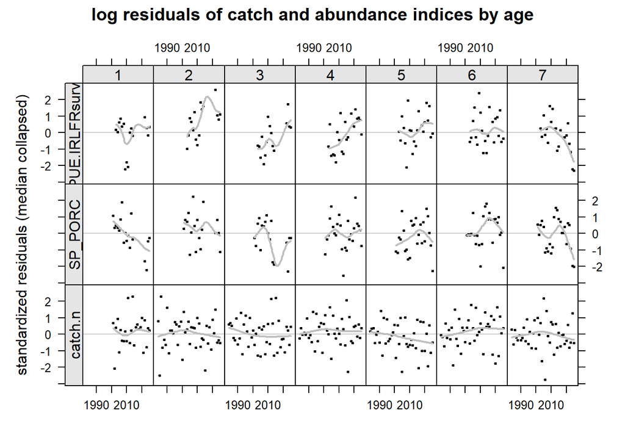

Figure 46: The catch-at-age and index-at-age (Porcupine and IRLFR) residuals in the assessment, after including mcmc and tensor in the fishing mortality.

### Observed and predicted catches plot

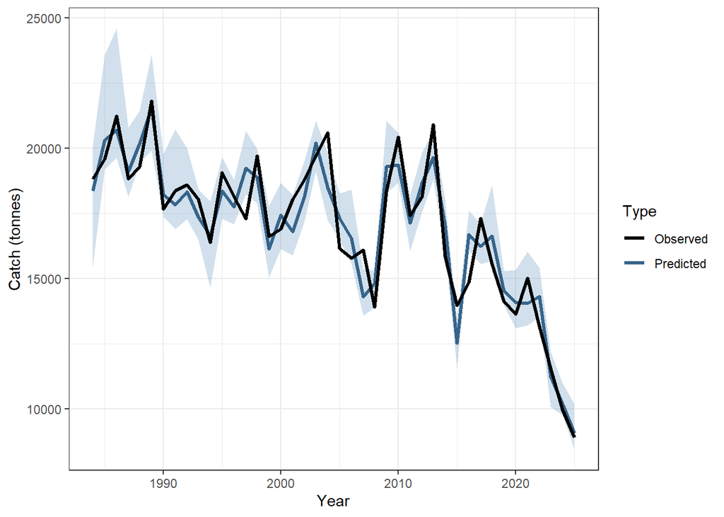

Figure 47: Comparison of observed and predicted catch in the assessment, after including mcmc and tensor in the fishing mortality.

```r
# save(stk1, stocks, stock, index, fit1, fits, file = "model/MegFit_Final_october.Rdata")
#
# save(fmod, qmod, srmod, vmod, n1mod, file = "model/SubModels_Final_october.Rdata")
```

## Fix the fishing mortality and catchability of old individuals

### Retrospective analysis plot

```r
# qmod <- list(~s(age, k = 4), ~s(age, k = 4))
# fmod <- ~te(age, year, k = c(5, 25))

qmod <- list(
  ~s(pmin(age, 5), k = 4),
  ~s(pmin(age, 4), k = 3)
)

# fmod <- ~te(age, year, k = c(5, 28))

fmod <- ~te(pmin(age, 6), year, k = c(3, 28))
```

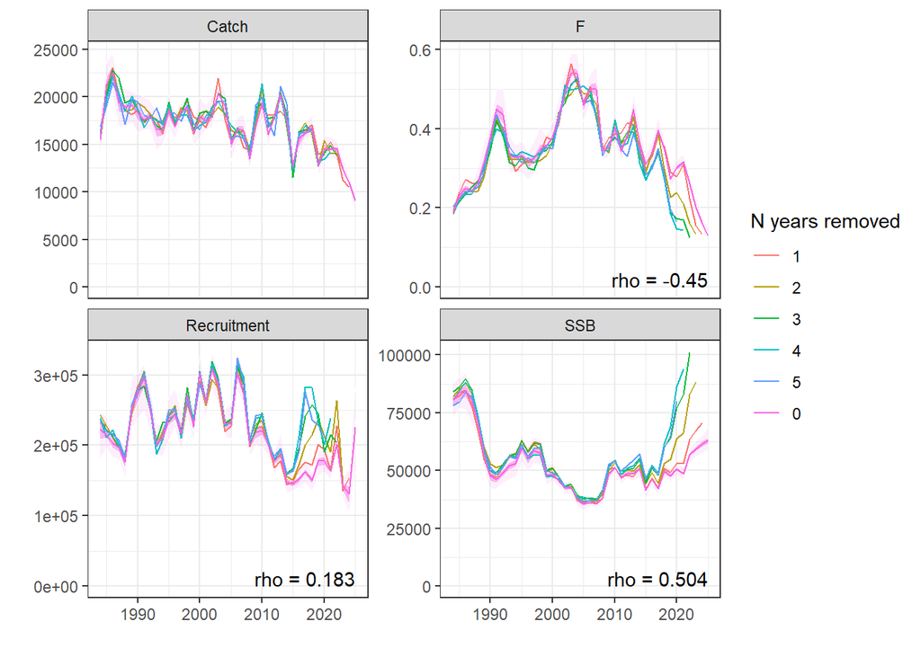

Figure 48: Retrospective analysis showing time series and Mohn’s rho values for median catch, fishing mortality (F, ages 3-6), recruitment (age 1), and spawning stock biomass (SSB), after including mcmc and tensor in the fishing mortality.

### Selectivity and catchability plot

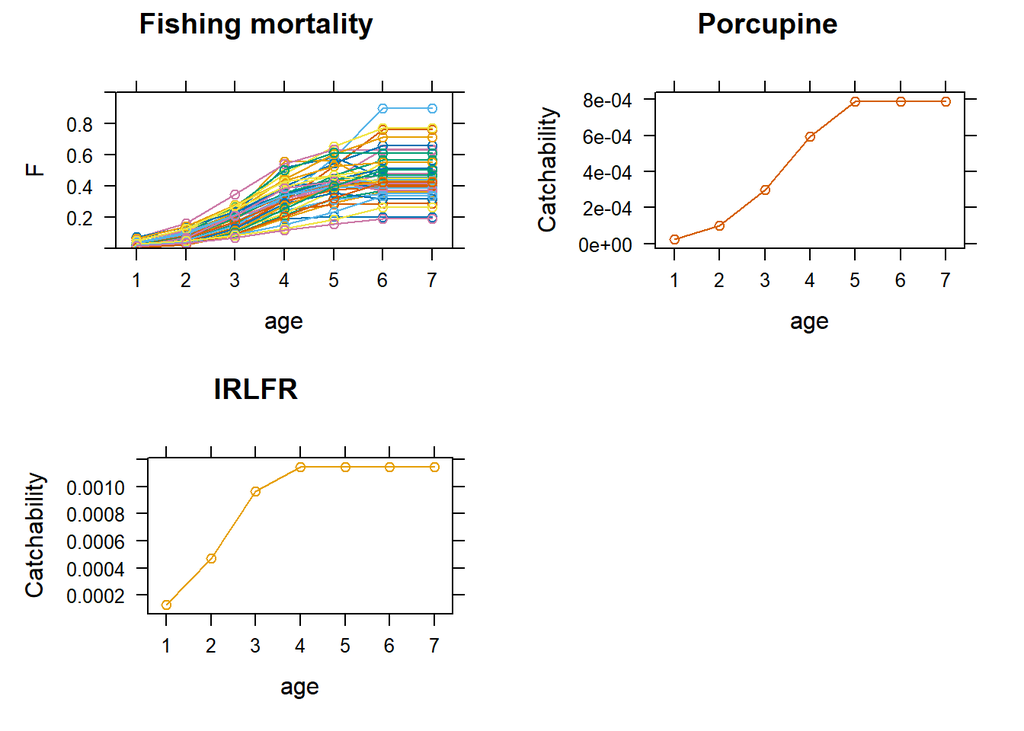

Figure 49: Fishery selectivity and indices catchabilities estimates from the assessment, after including mcmc and tensor in the fishing mortality.

### Residuals plot

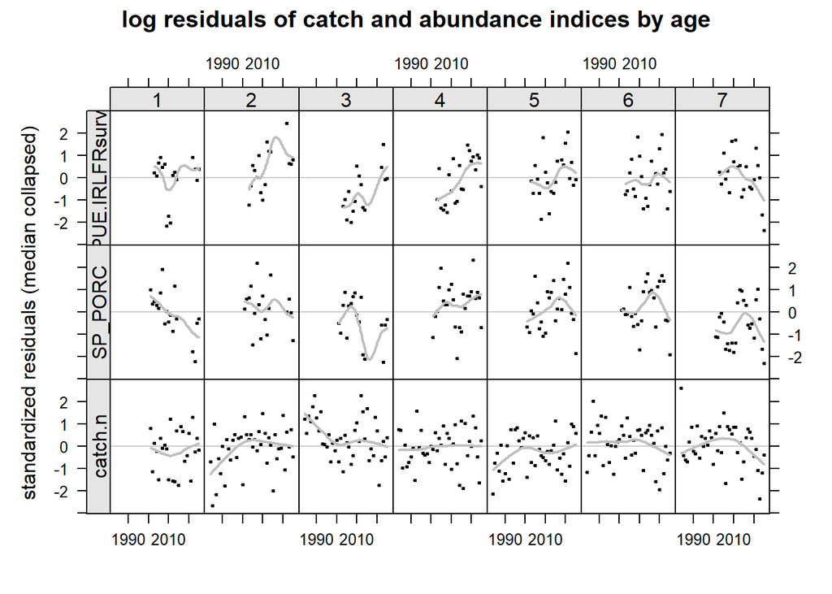

Figure 50: The catch-at-age and index-at-age (Porcupine and IRLFR) residuals in the assessment, after including mcmc and tensor in the fishing mortality.

### Observed and predicted catches plot

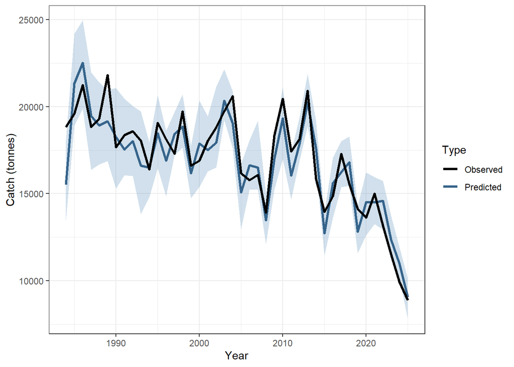

Figure 51: Comparison of observed and predicted catch in the assessment, after including mcmc and tensor in the fishing mortality.

```r
# save(stk1, stocks, stock, index, fit1, fits, file = "model/MegFit_Final_wd.Rdata")
#
# save(fmod, qmod, srmod, vmod, n1mod, file = "model/SubModels_Final_wd.Rdata")
```

# Future work

While we are aware of existing challenges and limitations in the current assessment framework, we are committed to continuing work on improving data quality, model accuracy, and biological understanding. The following areas have been identified as priorities for future investigation:

**Investigation of SOPs in input data** Further work is needed to understand the origin of the large SOPs observed in the input data provided by different countries. Clarifying these discrepancies will help improve data consistency and model reliability.

**Cohort tracking inconsistencies** Understanding the source of inconsistencies in cohort tracking - particularly in the Porcupine and IRLFR indices - could help improve confidence in the input data and, consequently, enhance the reliability of the assessment model. Further investigation is needed to determine why these indices fail to effectively track cohorts during the 2016-2020 period.

**Variability in age readings across countries** Differences in age readings between countries have been observed, which may have a considerable impact on the assessment model. To address this issue, a dedicated workshop is planned for 2026 with the aim of harmonizing age determination protocols across regions. Resolving these discrepancies could improve the consistency of input data and strengthen the robustness of model outputs.

**Incorporation of aging error** Investigating the potential inclusion of aging error in the assessment model could be a good option, as current data suggest that age readings may contain inaccuracies. Accounting for aging uncertainty could improve model performance and increase confidence in the assessment results. This aspect should be explored further in the near future.

**Weight-at-age trajectory of captured individuals** The catch data time series reveals a noticeable shift in the weight-at-age trajectory beginning in 2014. Further investigation is needed to understand the underlying causes of this change.

**Fishing selectivity** Fishing mortality for the oldest age groups has been assumed constant. Given that trawlers account for approximately 97% of the fishing effort in this fishery, the current selectivity pattern appears reasonable. However, this assumption should be critically evaluated through additional analysis to confirm its validity and assess potential biases.

**Combined vs. Separate Survey Indices** The EVHOE and IE-IGFS survey indices have been merged into a single composite index (IRLFR). In many stocks, combining indices improves performance by compensating for shifts in apparent distribution—where a decline in one index is offset by an increase in the other—resulting in a more coherent trend. Nevertheless, the suitability of this approach for the specific stock in question warrants further investigation.

**Improving Uncertainty Representation** Catch advice is currently provided in a deterministic way, without accounting for uncertainty in model fitting. Future developments should aim to incorporate and propagate parameter uncertainty within short-term forecasts to better reflect the range of plausible outcomes and strengthen the robustness of management advice. Methods such as Markov Chain Monte Carlo (MCMC) or the No-U-Turn Sampler (NUTS) could be used to estimate a distribution of possible parameter values, making forecasts more realistic and informative.

**Sexual dimorphism in biological parameters** There is notable sexual dimorphism between females and males, particularly in depth distribution and age-length relationships. In the Spanish age-length key, two distinct modes are evident, which may correspond to each sex. Future work should evaluate whether combining age data from both sexes affects model outcomes and whether a sex-specific assessment model would be beneficial.

**Catch allocation between *L.boscii* and *L.whiffiagonis*** It is important to review the accuracy of the current catch partitioning between *L. boscii* and *L. whiffiagonis*, as potential issues related to species identification may affect the reliability of the data. This is particularly relevant given that *L.boscii* matures earlier than *L.whiffiagonis*, which could influence biological interpretations and assessment outcomes.

**Catch below TAC levels** Over the past six years, total allowable catch (TAC) advice has consistently exceeded actual catches by more than 25%. This discrepancy is partly addressed in this working document through the correction of problematic cohorts - those that were estimated to have high abundances but subsequently disappeared at older ages. However, the underlying reasons for not reaching the TAC remain unclear and require further investigation. In discussions with ARVI (the Spanish fisheries cooperative responsible for most megrim catches in Spain), it was suggested that the lower catches may be due to reduced megrim biomass, or at least lower than in previous years. To better understand this trend, it is recommended to consult data providers from other countries to gather their perspectives and consider incorporating their insights into future assessments.

## References

ICES. 2023. “Benchmark Workshop on Selected Megrim Stocks (WKMEGRIM).” ICES Scientific Report 4:53. http://doi.org/10.17895/ices.pub.20069000.

———. 2025. “Working Group for the Bay of Biscay and Iberian Waters Ecoregion (WGBIE).” ICES Scientific Report 7:77. https://doi.org/10.17895/ices.pub.29390639.

Millar, C., and E. Jardim. 2019. “A4a: A Flexible and Robust Stock Assessment Framework.” https://flr-project.org/FLa4a/.